# Project: Investigate the Soccer Database

- Introduction
- Data Wrangling
- Exploratory Data Analysis
- Limitations
- Conclusions

## Introduction

> Soccer database originally posted on Kaggle (https://www.kaggle.com/hugomathien/soccer) is selected for analysis.

> From this dataset we are interested in knowing:
> - What teams improved the most over the time period?
> - Which players had the most penalties?
> - What team attributes lead to the most victories?
> - Is there any performance difference between the left-footed and right-footed players?
> - What are the attributes of top 10 players?

### *Setup*

> Since the original database is in SQL format, these lines are executed to bring the data into Pandas dataframe All the subsequent work is done in Pandas Each table in the original databse is moved into a new dataframe in Pandas

> The `Match` dataset has 115 columns which makes it cumbersome to work with so I decided to bring the first 11 columns only The remaining columns in Match dataset are related to the players positions in the games and betting acronyms which I am not going to use here

```python
# Data import

import pandas as pd
import numpy as np
import sqlite3 as sq
import matplotlib.pyplot as plt
import seaborn as sns
%matplotlib inline

sns.set_context('paper')
sns.set_style('whitegrid')

sqlite_file = 'C:/Users/akhan/Documents/Amir/Professional/Professional Development/Data/Udacity/Phase II/2_intro_to_data_analysis/2_project/database.sqlite/database.sqlite'
conn = sq.connect(sqlite_file)

df_country = pd.read_sql("""SELECT * FROM Country""", conn)
df_league = pd.read_sql("""SELECT * FROM League""", conn)
df_match = pd.read_sql(""" SELECT id,
                                        country_id,
                                        league_id,
                                        season,
                                        stage,
                                        date,
                                        match_api_id,
                                        home_team_api_id,
                                        away_team_api_id,
                                        home_team_goal,
                                        away_team_goal
                                FROM Match""", conn)
df_player = pd.read_sql("""SELECT * FROM Player""", conn)
df_player_att = pd.read_sql("""SELECT * FROM Player_Attributes""", conn)
df_team = pd.read_sql("""SELECT * FROM Team""", conn)
df_team_att = pd.read_sql("""SELECT * FROM Team_Attributes""", conn)

conn.close()
```

## Data Wrangling

> The Kaggle page provides a very convenient overview of what the data looks like, therefore some of the preliminary steps can be skipped here as the information is available there. Here is the list of information that was gained by looking at the Kaggle page using "column view"
> - `Country` is 11x2, has no missing values, foreign key: `id`
> - `League` is 11x3, has no missing values, foreign key: `country_id`
> - `Match` is 26k x 115 however we trimmed it to 26k x 11, has no missing values on the selected 11 columns, foreign keys: `country_id`,`league_id`,`home_team_api_id`,`away_team_api_id`
> - `Player` is 11.1k x 7, has no missing values, foreign key: `player_api_id`
> - `Player_Attributes` is 184k x 42, has various missing values as tested below ,foreign key: `player_api_id`
> - `Team` is 299 x 5, has limited missing values on column `team_fifa_api_id` which we will not use, foreign key: `team_api_id`
> - `Team_Attributes` is 1458 x 25, has 969 missing values on column `buildUpPlayDribbling` which we will not use, foreign key: `team_api_id`

```python
# Checking the missing data for 'Player_Attributes'

pd.isnull(df_player_att).sum()
```

```
id                        0
player_fifa_api_id        0
player_api_id             0
date                      0
overall_rating          836
potential               836
preferred_foot          836
attacking_work_rate    3230
defensive_work_rate     836
crossing                836
finishing               836
heading_accuracy        836
short_passing           836
volleys                2713
dribbling               836
curve                  2713
free_kick_accuracy      836
long_passing            836
ball_control            836
acceleration            836
sprint_speed            836
agility                2713
reactions               836
balance                2713
shot_power              836
jumping                2713
stamina                 836
strength                836
long_shots              836
aggression              836
interceptions           836
positioning             836
vision                 2713
penalties               836
marking                 836
standing_tackle         836
sliding_tackle         2713
gk_diving               836
gk_handling             836
gk_kicking              836
gk_positioning          836
gk_reflexes             836
dtype: int64
```

```python
# Checking 'Team_Attributes'

df_team_att.head()
```

|  | id | team_fifa_api_id | team_api_id | date | buildUpPlaySpeed | buildUpPlaySpeedClass | buildUpPlayDribbling | buildUpPlayDribblingClass | buildUpPlayPassing | buildUpPlayPassingClass | ... | chanceCreationShooting | chanceCreationShootingClass | chanceCreationPositioningClass | defencePressure | defencePressureClass | defenceAggression | defenceAggressionClass | defenceTeamWidth | defenceTeamWidthClass | defenceDefenderLineClass |
| --- | --- | --- | --- | --- | --- | --- | --- | --- | --- | --- | --- | --- | --- | --- | --- | --- | --- | --- | --- | --- | --- |
| 0 | 1 | 434 | 9930 | 2010-02-22 00:00:00 | 60 | Balanced | NaN | Little | 50 | Mixed | ... | 55 | Normal | Organised | 50 | Medium | 55 | Press | 45 | Normal | Cover |
| 1 | 2 | 434 | 9930 | 2014-09-19 00:00:00 | 52 | Balanced | 48.0 | Normal | 56 | Mixed | ... | 64 | Normal | Organised | 47 | Medium | 44 | Press | 54 | Normal | Cover |
| 2 | 3 | 434 | 9930 | 2015-09-10 00:00:00 | 47 | Balanced | 41.0 | Normal | 54 | Mixed | ... | 64 | Normal | Organised | 47 | Medium | 44 | Press | 54 | Normal | Cover |
| 3 | 4 | 77 | 8485 | 2010-02-22 00:00:00 | 70 | Fast | NaN | Little | 70 | Long | ... | 70 | Lots | Organised | 60 | Medium | 70 | Double | 70 | Wide | Cover |
| 4 | 5 | 77 | 8485 | 2011-02-22 00:00:00 | 47 | Balanced | NaN | Little | 52 | Mixed | ... | 52 | Normal | Organised | 47 | Medium | 47 | Press | 52 | Normal | Cover |

5 rows × 25 columns

```python
# Checking 'Match'

df_match.head()
```

|  | id | country_id | league_id | season | stage | date | match_api_id | home_team_api_id | away_team_api_id | home_team_goal | away_team_goal |
| --- | --- | --- | --- | --- | --- | --- | --- | --- | --- | --- | --- |
| 0 | 1 | 1 | 1 | 2008/2009 | 1 | 2008-08-17 00:00:00 | 492473 | 9987 | 9993 | 1 | 1 |
| 1 | 2 | 1 | 1 | 2008/2009 | 1 | 2008-08-16 00:00:00 | 492474 | 10000 | 9994 | 0 | 0 |
| 2 | 3 | 1 | 1 | 2008/2009 | 1 | 2008-08-16 00:00:00 | 492475 | 9984 | 8635 | 0 | 3 |
| 3 | 4 | 1 | 1 | 2008/2009 | 1 | 2008-08-17 00:00:00 | 492476 | 9991 | 9998 | 5 | 0 |
| 4 | 5 | 1 | 1 | 2008/2009 | 1 | 2008-08-16 00:00:00 | 492477 | 7947 | 9985 | 1 | 3 |

### Data preparation for question 1: *What teams improved the most over the time period?*

> For checking team improvement over time period, we could perhaps look at the information given in`Team_Attributes` and get a sense of team attributes over time however although this would be an indicative of the team performance, ultimately winning the matches is the most important factor. Because of this, I decided to look at the `Match` and check how many games each team won during the time period over several seasons to establish an improvement index for each team. The dataframe has the number of `home_team_goal` and `away_team_goal` so we can create 2 columns that represent the point each team gained for that match. For this the standard European league point system is used where the winner takes 3 points, loser takes 0 point and a tie results in 1 point for each team. This index will be used to compare the performance of each team yearly. Since we are dealing with dataframes `Match` and `Team`, we don't do any data cleaning and only joining between these two is required. In order to be able to make seasonal comparision, the column `season` also needs conversion from string to numeric.

```python
# Data preparation for question 1
# Adding the point columns to 'Match'

# Function to calculate the point based on European Football system
def point(col1, col2):
    goal_diff = col1 - col2
    if goal_diff > 0:
        return 3
    elif goal_diff == 0:
        return 1
    else:
        return 0

# Create two new columns for the teams points
df_match['home_team_point'] = df_match.apply(lambda x: point(x.home_team_goal,x.away_team_goal),axis=1)
df_match['away_team_point'] = df_match.apply(lambda x: point(x.away_team_goal,x.home_team_goal),axis=1)

# Inspection of the new dataframe
df_match.head()
```

|  | id | country_id | league_id | season | stage | date | match_api_id | home_team_api_id | away_team_api_id | home_team_goal | away_team_goal | home_team_point | away_team_point |
| --- | --- | --- | --- | --- | --- | --- | --- | --- | --- | --- | --- | --- | --- |
| 0 | 1 | 1 | 1 | 2008/2009 | 1 | 2008-08-17 00:00:00 | 492473 | 9987 | 9993 | 1 | 1 | 1 | 1 |
| 1 | 2 | 1 | 1 | 2008/2009 | 1 | 2008-08-16 00:00:00 | 492474 | 10000 | 9994 | 0 | 0 | 1 | 1 |
| 2 | 3 | 1 | 1 | 2008/2009 | 1 | 2008-08-16 00:00:00 | 492475 | 9984 | 8635 | 0 | 3 | 0 | 3 |
| 3 | 4 | 1 | 1 | 2008/2009 | 1 | 2008-08-17 00:00:00 | 492476 | 9991 | 9998 | 5 | 0 | 3 | 0 |
| 4 | 5 | 1 | 1 | 2008/2009 | 1 | 2008-08-16 00:00:00 | 492477 | 7947 | 9985 | 1 | 3 | 0 | 3 |

```python
# Checking the no of duplicates but it looks we are fine
df_match.duplicated().value_counts().mean() - df_match.count()
```

```
id                  0.0
country_id          0.0
league_id           0.0
season              0.0
stage               0.0
date                0.0
match_api_id        0.0
home_team_api_id    0.0
away_team_api_id    0.0
home_team_goal      0.0
away_team_goal      0.0
home_team_point     0.0
away_team_point     0.0
dtype: float64
```

```python
# Data preparation for question 1
# Looking at 'season' column in 'Match' grouped by 'home_team_api_id'

df_match_hometeam_season = df_match.groupby(['home_team_api_id','season']).sum().head(20)
df_match_hometeam_season
```

| home_team_api_id | season | id | country_id | league_id | stage | match_api_id | away_team_api_id | home_team_goal | away_team_goal | home_team_point | away_team_point |
| --- | --- | --- | --- | --- | --- | --- | --- | --- | --- | --- | --- |
| 1601 | 2008/2009 | 237671 | 235830 | 235830 | 225 | 7599572 | 100957 | 13 | 11 | 21 | 21 |
|  | 2009/2010 | 241199 | 235830 | 235830 | 240 | 10114842 | 100959 | 22 | 12 | 32 | 11 |
|  | 2010/2011 | 244823 | 235830 | 235830 | 240 | 12579284 | 100733 | 14 | 12 | 23 | 17 |
|  | 2011/2012 | 248457 | 235830 | 235830 | 225 | 15464544 | 100657 | 24 | 12 | 30 | 12 |
|  | 2012/2013 | 252115 | 235830 | 235830 | 240 | 18286129 | 106278 | 17 | 21 | 17 | 23 |
|  | 2013/2014 | 255540 | 235830 | 235830 | 225 | 22017216 | 105739 | 18 | 15 | 26 | 14 |
|  | 2014/2015 | 259092 | 235830 | 235830 | 255 | 25913833 | 106282 | 20 | 14 | 21 | 21 |
|  | 2015/2016 | 262878 | 235830 | 235830 | 210 | 29920857 | 275068 | 20 | 26 | 20 | 23 |
| 1773 | 2011/2012 | 13065 | 15 | 15 | 240 | 15492238 | 143670 | 25 | 24 | 20 | 20 |
|  | 2012/2013 | 16837 | 15 | 15 | 225 | 18361475 | 142133 | 26 | 27 | 21 | 18 |
|  | 2015/2016 | 24153 | 15 | 15 | 240 | 29699459 | 405321 | 23 | 22 | 20 | 23 |
| 1957 | 2008/2009 | 237588 | 235830 | 235830 | 236 | 7599609 | 100601 | 24 | 15 | 29 | 14 |
|  | 2009/2010 | 241465 | 235830 | 235830 | 225 | 10114103 | 100603 | 18 | 6 | 32 | 8 |
|  | 2010/2011 | 245071 | 235830 | 235830 | 240 | 12579293 | 100377 | 29 | 11 | 35 | 8 |
|  | 2011/2012 | 248493 | 235830 | 235830 | 225 | 15464440 | 100301 | 23 | 14 | 32 | 11 |
|  | 2012/2013 | 251906 | 235830 | 235830 | 225 | 18286159 | 105922 | 13 | 19 | 18 | 21 |
|  | 2013/2014 | 255595 | 235830 | 235830 | 255 | 22017412 | 105383 | 28 | 18 | 22 | 19 |
|  | 2014/2015 | 259247 | 235830 | 235830 | 225 | 25833135 | 105926 | 25 | 18 | 27 | 15 |
|  | 2015/2016 | 262901 | 235830 | 235830 | 225 | 29920952 | 274712 | 16 | 22 | 21 | 21 |
| 2033 | 2009/2010 | 270115 | 264630 | 264630 | 225 | 10293275 | 138352 | 12 | 18 | 17 | 23 |

```python
# Data preparation for question 1

# Dropping unnecessary columns
df_match.drop(['date','country_id','league_id','stage','match_api_id'],axis=1)

# Adding 'season_id' column for dat regression next
df_match['season_id'] = df_match['season'].str[:4].astype(int)-2008
df_match.head()
```

|  | id | country_id | league_id | season | stage | date | match_api_id | home_team_api_id | away_team_api_id | home_team_goal | away_team_goal | home_team_point | away_team_point | season_id |
| --- | --- | --- | --- | --- | --- | --- | --- | --- | --- | --- | --- | --- | --- | --- |
| 0 | 1 | 1 | 1 | 2008/2009 | 1 | 2008-08-17 00:00:00 | 492473 | 9987 | 9993 | 1 | 1 | 1 | 1 | 0 |
| 1 | 2 | 1 | 1 | 2008/2009 | 1 | 2008-08-16 00:00:00 | 492474 | 10000 | 9994 | 0 | 0 | 1 | 1 | 0 |
| 2 | 3 | 1 | 1 | 2008/2009 | 1 | 2008-08-16 00:00:00 | 492475 | 9984 | 8635 | 0 | 3 | 0 | 3 | 0 |
| 3 | 4 | 1 | 1 | 2008/2009 | 1 | 2008-08-17 00:00:00 | 492476 | 9991 | 9998 | 5 | 0 | 3 | 0 | 0 |
| 4 | 5 | 1 | 1 | 2008/2009 | 1 | 2008-08-16 00:00:00 | 492477 | 7947 | 9985 | 1 | 3 | 0 | 3 | 0 |

```python
# checking for duplicates first, it seems fine running the following two lines

df_player.count() - df_player.duplicated().value_counts().mean()
```

```
id                    0.0
player_api_id         0.0
player_name           0.0
player_fifa_api_id    0.0
birthday              0.0
height                0.0
weight                0.0
dtype: float64
```

```python
# grouping by season_id to see how many season are there in general
df_match.groupby(['season_id']).sum()
```

| season_id | id | country_id | league_id | stage | match_api_id | home_team_api_id | away_team_api_id | home_team_goal | away_team_goal | home_team_point | away_team_point |
| --- | --- | --- | --- | --- | --- | --- | --- | --- | --- | --- | --- |
| 0 | 38440859 | 37913476 | 37913476 | 60921 | 1696989363 | 29865752 | 29865752 | 5007 | 3665 | 5529 | 3618 |
| 1 | 39444759 | 37913380 | 37913380 | 58821 | 2186440252 | 28992934 | 28995818 | 4978 | 3654 | 5410 | 3466 |
| 2 | 40475560 | 37913410 | 37913410 | 59286 | 2790634344 | 31266636 | 31266636 | 5048 | 3701 | 5399 | 3542 |
| 3 | 40783942 | 37245712 | 37245712 | 58203 | 3353773417 | 28643228 | 28644597 | 5064 | 3683 | 5312 | 3530 |
| 4 | 42508072 | 37913410 | 37913410 | 59286 | 4046588499 | 29234544 | 29234544 | 5053 | 3986 | 5185 | 3742 |
| 5 | 43219478 | 37913182 | 37913182 | 55608 | 4517367496 | 29443941 | 29440409 | 4787 | 3602 | 4948 | 3412 |
| 6 | 45761967 | 39067525 | 39067525 | 60883 | 5788006607 | 36295531 | 36297489 | 5055 | 3842 | 5332 | 3793 |
| 7 | 46832573 | 39077782 | 39077782 | 60921 | 6676254169 | 45641434 | 45641434 | 5135 | 4027 | 5232 | 3891 |

### Data preparation for question 2: *Which players had the most penalties?*

> This seems somewhat straighforward since `Player_Attributes` has a column as `penalties` which is assumed to be the player's number of penalties and one can get this value without too much data wrangling. As shown above `Player_Attributes` has various missing data with the most common number being 836 values for 30 columns. Given the columns length being 184k, dropping 836 values seems trivial (0.5% of total) so we will go ahead and do that for sure. This will clean up the column penalties and should be sufficient for answering this question.

```python
# Data preparation for question 2
# As discussed above, we go ahead and drop 836 missing data based on the 'overall_rating' in dataframe 'df_player_att'

df_player_att.dropna(subset=['overall_rating'], how='all', inplace=True)

# Checking for nulls
pd.isnull(df_player_att).sum()
```

```
id                        0
player_fifa_api_id        0
player_api_id             0
date                      0
overall_rating            0
potential                 0
preferred_foot            0
attacking_work_rate    2394
defensive_work_rate       0
crossing                  0
finishing                 0
heading_accuracy          0
short_passing             0
volleys                1877
dribbling                 0
curve                  1877
free_kick_accuracy        0
long_passing              0
ball_control              0
acceleration              0
sprint_speed              0
agility                1877
reactions                 0
balance                1877
shot_power                0
jumping                1877
stamina                   0
strength                  0
long_shots                0
aggression                0
interceptions             0
positioning               0
vision                 1877
penalties                 0
marking                   0
standing_tackle           0
sliding_tackle         1877
gk_diving                 0
gk_handling               0
gk_kicking                0
gk_positioning            0
gk_reflexes               0
dtype: int64
```

```python
# Checking the updated list of columns
df_team_att.columns
```

```
Index(['id', 'team_fifa_api_id', 'team_api_id', 'date', 'buildUpPlaySpeed',
       'buildUpPlaySpeedClass', 'buildUpPlayDribbling',
       'buildUpPlayDribblingClass', 'buildUpPlayPassing',
       'buildUpPlayPassingClass', 'buildUpPlayPositioningClass',
       'chanceCreationPassing', 'chanceCreationPassingClass',
       'chanceCreationCrossing', 'chanceCreationCrossingClass',
       'chanceCreationShooting', 'chanceCreationShootingClass',
       'chanceCreationPositioningClass', 'defencePressure',
       'defencePressureClass', 'defenceAggression', 'defenceAggressionClass',
       'defenceTeamWidth', 'defenceTeamWidthClass',
       'defenceDefenderLineClass'],
      dtype='object')
```

### Data preparation for question 3: *What team attributes lead to the most victories?*

> There are a number of numerics available in `Team_Attributes` which can be used to the team victories which is obtained within question 1. There is no cleaning needed for this dataframe however to make it more convenient we could drop the non-numeric columns as we won't be using them

```python
# Data preparation for question 3
# Dropping non-numeric values on 'Team_Attributes'

to_be_dropped_cols = []

for c in df_team_att.columns:
    if c[-5:] == "Class":
        to_be_dropped_cols.append(c)

for d in to_be_dropped_cols:
    df_team_att.drop(d, axis=1, inplace = True)

df_team_att.head()
```

|  | id | team_fifa_api_id | team_api_id | date | buildUpPlaySpeed | buildUpPlayDribbling | buildUpPlayPassing | chanceCreationPassing | chanceCreationCrossing | chanceCreationShooting | defencePressure | defenceAggression | defenceTeamWidth |
| --- | --- | --- | --- | --- | --- | --- | --- | --- | --- | --- | --- | --- | --- |
| 0 | 1 | 434 | 9930 | 2010-02-22 00:00:00 | 60 | NaN | 50 | 60 | 65 | 55 | 50 | 55 | 45 |
| 1 | 2 | 434 | 9930 | 2014-09-19 00:00:00 | 52 | 48.0 | 56 | 54 | 63 | 64 | 47 | 44 | 54 |
| 2 | 3 | 434 | 9930 | 2015-09-10 00:00:00 | 47 | 41.0 | 54 | 54 | 63 | 64 | 47 | 44 | 54 |
| 3 | 4 | 77 | 8485 | 2010-02-22 00:00:00 | 70 | NaN | 70 | 70 | 70 | 70 | 60 | 70 | 70 |
| 4 | 5 | 77 | 8485 | 2011-02-22 00:00:00 | 47 | NaN | 52 | 53 | 48 | 52 | 47 | 47 | 52 |

```python
# Data preparation for question 3
# As discussed, the column 'buildUpPlayDribbling' seems to have many Nan values so we will go ahead and drop this column also
df_team_att.drop(['buildUpPlayDribbling'], axis=1, inplace = True)
df_team_att.head()
```

|  | id | team_fifa_api_id | team_api_id | date | buildUpPlaySpeed | buildUpPlayPassing | chanceCreationPassing | chanceCreationCrossing | chanceCreationShooting | defencePressure | defenceAggression | defenceTeamWidth |
| --- | --- | --- | --- | --- | --- | --- | --- | --- | --- | --- | --- | --- |
| 0 | 1 | 434 | 9930 | 2010-02-22 00:00:00 | 60 | 50 | 60 | 65 | 55 | 50 | 55 | 45 |
| 1 | 2 | 434 | 9930 | 2014-09-19 00:00:00 | 52 | 56 | 54 | 63 | 64 | 47 | 44 | 54 |
| 2 | 3 | 434 | 9930 | 2015-09-10 00:00:00 | 47 | 54 | 54 | 63 | 64 | 47 | 44 | 54 |
| 3 | 4 | 77 | 8485 | 2010-02-22 00:00:00 | 70 | 70 | 70 | 70 | 70 | 60 | 70 | 70 |
| 4 | 5 | 77 | 8485 | 2011-02-22 00:00:00 | 47 | 52 | 53 | 48 | 52 | 47 | 47 | 52 |

### Data preparation for question 4: *Is there any performance difference between the left-footed and right-footed players?*

> This is just for fun and doesn't have a major significance. For this, we would be looking at `prefered_foot` available in `Player_Attribute` and see how the left-footed ones compare with the rest of the players. The data preparation done for question 2 would be sufficient for this also

### Data preparation for question 5: *What are the attributes of top 10 players?*

> For this we would be looking at `overall_rating` available again in `Player_Attribute` and select the 10 top rated players and compare them with the rest of the players. Likewise The data preparation done for question 2 would be sufficient for this also.

## Exploratory Data Analysis

### Research Question 1: What teams improved the most over the time period?

> Now that we have cleaned up 'Match' dataset and have the score of each team available. we can go through a few steps to establish an "improvement index". The steps would be:
> - Find the total point each team accumulated on each season
> - Do a linear regression fit over the total point of each team where x-axis would be season and y-axis would be total points
> - Check the slope of the linear regression line for each team and find the steepest slope which implies the best team progress over several seasons

```python
# First we group the 'Match' by 'home_team_api_id' and 'season_id' and sum the number to have total points for 'home_team_point'
df_match_team_season = df_match.groupby(['home_team_api_id','season_id']).sum()

# Checking the result
df_match_team_season.head(20)
```

| home_team_api_id | season_id | id | country_id | league_id | stage | match_api_id | away_team_api_id | home_team_goal | away_team_goal | home_team_point | away_team_point |
| --- | --- | --- | --- | --- | --- | --- | --- | --- | --- | --- | --- |
| 1601 | 0 | 237671 | 235830 | 235830 | 225 | 7599572 | 100957 | 13 | 11 | 21 | 21 |
|  | 1 | 241199 | 235830 | 235830 | 240 | 10114842 | 100959 | 22 | 12 | 32 | 11 |
|  | 2 | 244823 | 235830 | 235830 | 240 | 12579284 | 100733 | 14 | 12 | 23 | 17 |
|  | 3 | 248457 | 235830 | 235830 | 225 | 15464544 | 100657 | 24 | 12 | 30 | 12 |
|  | 4 | 252115 | 235830 | 235830 | 240 | 18286129 | 106278 | 17 | 21 | 17 | 23 |
|  | 5 | 255540 | 235830 | 235830 | 225 | 22017216 | 105739 | 18 | 15 | 26 | 14 |
|  | 6 | 259092 | 235830 | 235830 | 255 | 25913833 | 106282 | 20 | 14 | 21 | 21 |
|  | 7 | 262878 | 235830 | 235830 | 210 | 29920857 | 275068 | 20 | 26 | 20 | 23 |
| 1773 | 3 | 13065 | 15 | 15 | 240 | 15492238 | 143670 | 25 | 24 | 20 | 20 |
|  | 4 | 16837 | 15 | 15 | 225 | 18361475 | 142133 | 26 | 27 | 21 | 18 |
|  | 7 | 24153 | 15 | 15 | 240 | 29699459 | 405321 | 23 | 22 | 20 | 23 |
| 1957 | 0 | 237588 | 235830 | 235830 | 236 | 7599609 | 100601 | 24 | 15 | 29 | 14 |
|  | 1 | 241465 | 235830 | 235830 | 225 | 10114103 | 100603 | 18 | 6 | 32 | 8 |
|  | 2 | 245071 | 235830 | 235830 | 240 | 12579293 | 100377 | 29 | 11 | 35 | 8 |
|  | 3 | 248493 | 235830 | 235830 | 225 | 15464440 | 100301 | 23 | 14 | 32 | 11 |
|  | 4 | 251906 | 235830 | 235830 | 225 | 18286159 | 105922 | 13 | 19 | 18 | 21 |
|  | 5 | 255595 | 235830 | 235830 | 255 | 22017412 | 105383 | 28 | 18 | 22 | 19 |
|  | 6 | 259247 | 235830 | 235830 | 225 | 25833135 | 105926 | 25 | 18 | 27 | 15 |
|  | 7 | 262901 | 235830 | 235830 | 225 | 29920952 | 274712 | 16 | 22 | 21 | 21 |
| 2033 | 1 | 270115 | 264630 | 264630 | 225 | 10293275 | 138352 | 12 | 18 | 17 | 23 |

> Fitting a linear regression line to each team where x-axis would be 'season_id' and y-axis would be 'home_team_point' First we try on only one team to see if approach works

```python
# we select the first team with 'home_team_api_id' = 1601 for testing regression
x = df_match_team_season.loc[(1601,)]['home_team_point'].index
y = df_match_team_season.loc[(1601,)]['home_team_point'][:]
m,b = np.polyfit(x, y, 1)

print('slope for team 1601 is: ', m, '| offset for team 1601 is: ', b)
```

```
slope for team 1601 is:  -0.7857142857142847 | offset for team 1601 is:  26.499999999999993
```

> We now have slope and offset of the refression line which we only need slope to compare the teams by

> Now let us check whether the linear regression makes sense and is done correctly by looking at the line plot

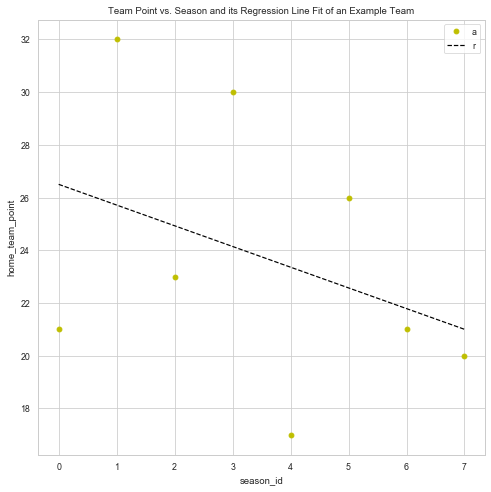

```python
# This is for plotting the regression line
coeff = m,b
poly1d_fn = np.poly1d(coeff)

plt.figure(figsize=(8,8))
plt.plot(x,y, 'yo', x, poly1d_fn(x), '--k')

plt.legend('ar')
plt.title('Team Point vs. Season and its Regression Line Fit of an Example Team')

plt.xlabel('season_id')
plt.ylabel('home_team_point');
```

> The approach seems to be working. now we apply the same method to all teams and find the maximum value for the positive slope which indicates the maximum improvement

```python
# Getting the teams indexes
home_team_api_id = df_match.home_team_api_id.drop_duplicates().tolist()

# empty dictionary for saving the team indexes and their slopes in
m_all = {}

# regression operation for all teams
for h in home_team_api_id:
    m = 0
    b = 0
    x = df_match_team_season.loc[(h,)]['home_team_point'].index
    y = df_match_team_season.loc[(h,)]['home_team_point'][:]
    if len(x) >1:
        m,b = np.polyfit(x, y, 1)
# Add all the slopes to a dictiorary while preserving the 'home_team_api_id' as keys
    m_all[h] = m

# Checking the dictonary that contains all the regression slopes
m_all
```

```
{9987: 1.1811594202898545,
 10000: -1.1340579710144936,
 9984: -2.814285714285711,
 9991: -0.45238095238095,
 7947: 0,
 8203: -0.1304347826086958,
 9999: -12.999999999999996,
 4049: 0,
 10001: -1.1974248927038635,
 8342: 0.7499999999999983,
 9985: -1.659420289855074,
 9994: -0.8731884057971021,
 9996: 0,
 9993: -2.4,
 8635: -1.134057971014494,
```

[output cut: 284 more lines]

```python
# Finding the maxium slope and the team associated with it
max_slope_team_api_id = max(m_all, key=m_all.get)
max_slope_team_api_id
```

```
8197
```

```python
# Finding the maxium slope

m_values = m_all.values()
max_m = max(m_values)

# Printing the maximum positive slope
max_m
```

```
15.999999999999963
```

Now that we know which team made the most improvement, let's have a look at its points over all seasons, graphically

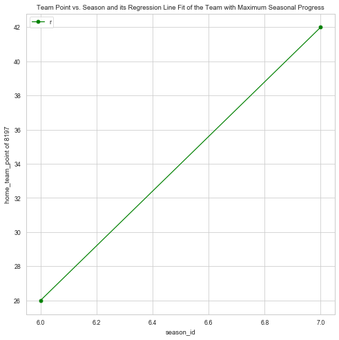

```python
# Preparation for the plotting
x_max = df_match_team_season.loc[(max_slope_team_api_id,)]['home_team_point'].index
y_max = df_match_team_season.loc[(max_slope_team_api_id,)]['home_team_point'][:]

# line plot
plt.figure(figsize=(8,8))
plt.plot(x_max,y_max,'-go');

plt.legend('r')
plt.title('Team Point vs. Season and its Regression Line Fit of the Team with Maximum Seasonal Progress')

plt.xlabel('season_id')
plt.ylabel('home_team_point of 8197');
```

> It appears this team only played in two seasons. While low seasoanal appearance is not great for our regression fit analysis this answers the question we set out in the begining as Question 1

> We could filter the teams more to capture only the teams with higher seasonal participation but I am leaving the analysis as is at this point

```python
# Finding the name of the team with maximum improvement
df_max_team = df_team[df_team['team_api_id'] == max_slope_team_api_id]
df_max_team
```

|  | id | team_api_id | team_fifa_api_id | team_long_name | team_short_name |
| --- | --- | --- | --- | --- | --- |
| 56 | 8021 | 8197 | 95.0 | Leicester City | LEI |

This concludes the work related to Question 1

### Research Question 2: Which players had the most penalties?

> For this we look into `penalties` number available in `df_player_att` dataframe which is already cleaned above. There is ambiguity on whether this feature represents what we are looking for so I looked into http://sofifa.com/ as referenced in Kaggle page and it is still a bit unclear if this is the number of the penalties a player actually scored or this is a quality rating of the specific player. I have assumed the former meaning this number actually represents the number of penalties a player scored

```python
# Let's first have a look at the 'df_player_att' sorted by 'penalties'
df_player_att_max_penalties = df_player_att.sort_values(by=['penalties'], ascending=False).head(8)
df_player_att_max_penalties
```

|  | id | player_fifa_api_id | player_api_id | date | overall_rating | potential | preferred_foot | attacking_work_rate | defensive_work_rate | crossing | ... | vision | penalties | marking | standing_tackle | sliding_tackle | gk_diving | gk_handling | gk_kicking | gk_positioning | gk_reflexes |
| --- | --- | --- | --- | --- | --- | --- | --- | --- | --- | --- | --- | --- | --- | --- | --- | --- | --- | --- | --- | --- | --- |
| 149594 | 149595 | 13879 | 39225 | 2015-09-21 00:00:00 | 75.0 | 75.0 | right | high | medium | 67.0 | ... | 77.0 | 96.0 | 30.0 | 26.0 | 19.0 | 13.0 | 15.0 | 7.0 | 16.0 | 11.0 |
| 149593 | 149594 | 13879 | 39225 | 2015-10-23 00:00:00 | 75.0 | 75.0 | right | high | medium | 67.0 | ... | 77.0 | 96.0 | 30.0 | 26.0 | 19.0 | 13.0 | 15.0 | 7.0 | 16.0 | 11.0 |
| 149592 | 149593 | 13879 | 39225 | 2015-12-24 00:00:00 | 75.0 | 75.0 | right | high | medium | 67.0 | ... | 77.0 | 96.0 | 30.0 | 26.0 | 19.0 | 13.0 | 15.0 | 7.0 | 16.0 | 11.0 |
| 149591 | 149592 | 13879 | 39225 | 2016-03-10 00:00:00 | 75.0 | 75.0 | right | high | medium | 67.0 | ... | 77.0 | 96.0 | 30.0 | 26.0 | 19.0 | 13.0 | 15.0 | 7.0 | 16.0 | 11.0 |
| 149595 | 149596 | 13879 | 39225 | 2015-02-27 00:00:00 | 76.0 | 76.0 | right | high | medium | 66.0 | ... | 76.0 | 95.0 | 29.0 | 25.0 | 25.0 | 12.0 | 14.0 | 6.0 | 15.0 | 10.0 |
| 113528 | 113529 | 186627 | 108808 | 2013-05-17 00:00:00 | 84.0 | 90.0 | right | medium | low | 67.0 | ... | 75.0 | 95.0 | 20.0 | 21.0 | 11.0 | 13.0 | 6.0 | 11.0 | 6.0 | 8.0 |
| 113521 | 113522 | 186627 | 108808 | 2014-01-24 00:00:00 | 84.0 | 90.0 | right | medium | low | 67.0 | ... | 75.0 | 95.0 | 25.0 | 25.0 | 25.0 | 13.0 | 6.0 | 11.0 | 6.0 | 8.0 |
| 113522 | 113523 | 186627 | 108808 | 2013-12-20 00:00:00 | 84.0 | 90.0 | right | medium | low | 67.0 | ... | 75.0 | 95.0 | 25.0 | 25.0 | 25.0 | 13.0 | 6.0 | 11.0 | 6.0 | 8.0 |

8 rows × 42 columns

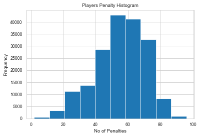

```python
# First let's get a sense of penalties distribution
df_player_att.penalties.hist()
plt.title('Players Penalty Histogram')
plt.xlabel('No of Penalties')
plt.ylabel('Frequency');
```

> From above histogram, it looks the penalties distribution is fairly normal and slightly left skewed

```python
# Let's find the maximum value
df_player_att_max_penalties.penalties.max()
```

```
96.0
```

```python
# We can group the 'df_player_att' by 'penalties' and show the highest values
df_player_att_index = df_player_att_max_penalties['penalties'].idxmax()

# Printing the index of the player with maximum penalties
df_player_att_index
```

```
149594
```

```python
# Looking at the attributes of the player with maximum penalties
df_player_att_max_penalties.iloc[0]
```

```
id                                  149595
player_fifa_api_id                   13879
player_api_id                        39225
date                   2015-09-21 00:00:00
overall_rating                          75
potential                               75
preferred_foot                       right
attacking_work_rate                   high
defensive_work_rate                 medium
crossing                                67
finishing                               81
heading_accuracy                        84
short_passing                           66
volleys                                 72
dribbling                               65
curve                                   77
free_kick_accuracy                      84
long_passing                            72
ball_control                            75
acceleration                            48
sprint_speed                            46
agility                                 57
reactions                               75
balance                                 59
shot_power                              85
jumping                                 71
stamina                                 71
strength                                85
long_shots                              74
aggression                              76
interceptions                           32
positioning                             79
vision                                  77
penalties                               96
marking                                 30
standing_tackle                         26
sliding_tackle                          19
gk_diving                               13
gk_handling                             15
gk_kicking                               7
gk_positioning                          16
gk_reflexes                             11
Name: 149594, dtype: object
```

> It appears the player with the highest penalty rating has the `player_api_id` == 39225

```python
# Now we try to get his/her name by looking it up in 'df_player'

df_player[df_player['player_api_id'] == 39225]
```

|  | id | player_api_id | player_name | player_fifa_api_id | birthday | height | weight |
| --- | --- | --- | --- | --- | --- | --- | --- |
| 8967 | 8981 | 39225 | Rickie Lambert | 13879 | 1982-02-16 00:00:00 | 187.96 | 170 |

This concludes the work related to Question 2

### Research Question 3: What team attributes lead to the most victories?

> As mentioned above, there are a number of numerics available in `Team_Attributes` which can be used to link them to the team victories. First we find which team had the highest point overall in all seasons which we get from `match`

```python
# First let's get the maximum point any team earned
df_match_team_season['home_team_point'].max()
```

```
57
```

```python
# Now we get the index of the team that got the maximum point

df_match_team_season['home_team_point'].idxmax()
```

```
(9885, 5)
```

```python
# Let's look at this team and their performance over all seasons

df_match_team_season.loc[(9885, )]
```

| season_id | id | country_id | league_id | stage | match_api_id | away_team_api_id | home_team_goal | away_team_goal | home_team_point | away_team_point |
| --- | --- | --- | --- | --- | --- | --- | --- | --- | --- | --- |
| 0 | 198499 | 194883 | 194883 | 380 | 10255281 | 171000 | 38 | 19 | 39 | 12 |
| 1 | 205398 | 194883 | 194883 | 361 | 13391817 | 171298 | 32 | 26 | 31 | 22 |
| 2 | 212927 | 194883 | 194883 | 380 | 16878724 | 175312 | 35 | 31 | 30 | 21 |
| 3 | 208693 | 184626 | 184626 | 350 | 19497310 | 159065 | 37 | 12 | 42 | 6 |
| 4 | 226648 | 194883 | 194883 | 361 | 24455875 | 172467 | 36 | 10 | 45 | 9 |
| 5 | 234173 | 194883 | 194883 | 380 | 29197568 | 171854 | 47 | 9 | 57 | 0 |
| 6 | 241370 | 194883 | 194883 | 380 | 33937541 | 171884 | 45 | 11 | 51 | 3 |
| 7 | 248791 | 194883 | 194883 | 380 | 39148583 | 371987 | 37 | 6 | 50 | 5 |

> Looks like this team earned 57 points on `season_id` of 5

```python
# Let's find out the name of this team
df_team[df_team['team_api_id'] == 9885]
```

|  | id | team_api_id | team_fifa_api_id | team_long_name | team_short_name |
| --- | --- | --- | --- | --- | --- |
| 133 | 20522 | 9885 | 45.0 | Juventus | JUV |

> yay, I am a big fan of Juventus, now we look at all teams mean value to compare Juventus with it

```python
# Getting the mean value of all teams
team_att_means = df_team_att.mean()[3:]
team_att_means
```

```
buildUpPlaySpeed          52.462277
buildUpPlayPassing        48.490398
chanceCreationPassing     52.165295
chanceCreationCrossing    53.731824
chanceCreationShooting    53.969136
defencePressure           46.017147
defenceAggression         49.251029
defenceTeamWidth          52.185871
dtype: float64
```

```python
# Let's get the mean values of team juventus attributes
team_att_juventus = df_team_att[df_team_att['team_api_id'] == 9885].mean()[3:]
team_att_juventus
```

```
buildUpPlaySpeed          45.833333
buildUpPlayPassing        32.833333
chanceCreationPassing     56.666667
chanceCreationCrossing    60.500000
chanceCreationShooting    65.666667
defencePressure           44.000000
defenceAggression         57.333333
defenceTeamWidth          41.166667
dtype: float64
```

> To find out how juventus compares with the means of all team, we can divide their performance attributes by the means of all teams

```python
# Scaling Juventus against all other teams
team_att_juventus_scale = team_att_juventus / team_att_means
team_att_juventus_scale
```

```
buildUpPlaySpeed          0.873644
buildUpPlayPassing        0.677110
chanceCreationPassing     1.086291
chanceCreationCrossing    1.125962
chanceCreationShooting    1.216745
defencePressure           0.956165
defenceAggression         1.164104
defenceTeamWidth          0.788847
dtype: float64
```

> Well it looks like juventus is better in 4 factors but not above the mean in other 4 factors

> It's a good idea now to check if there is any relation between team performance and team attributes by plotting some of the variables

> First we put the total point of each team into a dataframe grouped by `home_team_api_id`

```python
# grouping all teams and summing their values
df_match_hometeam_point_sum = df_match.groupby('home_team_api_id').sum()
df_match_hometeam_point_sum
```

| home_team_api_id | id | country_id | league_id | stage | match_api_id | away_team_api_id | home_team_goal | away_team_goal | home_team_point | away_team_point | season_id |
| --- | --- | --- | --- | --- | --- | --- | --- | --- | --- | --- | --- |
| 1601 | 2001775 | 1886640 | 1886640 | 1860 | 141896277 | 996673 | 148 | 123 | 190 | 142 | 420 |
| 1773 | 54055 | 45 | 45 | 705 | 63553172 | 691124 | 74 | 73 | 61 | 61 | 210 |
| 1957 | 2002266 | 1886640 | 1886640 | 1856 | 141815103 | 993825 | 176 | 123 | 216 | 117 | 420 |
| 2033 | 1386280 | 1323150 | 1323150 | 1155 | 80153313 | 843557 | 70 | 92 | 84 | 114 | 225 |
| 2182 | 2001652 | 1886640 | 1886640 | 1920 | 141817943 | 992025 | 215 | 91 | 249 | 84 | 420 |
| ... | ... | ... | ... | ... | ... | ... | ... | ... | ... | ... | ... |
| 158085 | 943492 | 864458 | 864458 | 837 | 86491815 | 617139 | 56 | 62 | 65 | 71 | 296 |
| 177361 | 262901 | 235830 | 235830 | 240 | 29921088 | 99308 | 21 | 19 | 19 | 22 | 105 |
| 188163 | 332198 | 299914 | 299914 | 289 | 34271283 | 301606 | 15 | 26 | 13 | 34 | 119 |
| 208931 | 248729 | 194883 | 194883 | 361 | 39148552 | 172941 | 23 | 26 | 23 | 29 | 133 |
| 274581 | 44614 | 30 | 30 | 450 | 55468304 | 273229 | 41 | 46 | 34 | 49 | 195 |

299 rows × 11 columns

> Then we put the mean attribute indexes of each team into a dataframe grouped by `team_api_id`

```python
# Getting the mean attribute indexes of each team

df_team_att_team_means = df_team_att.groupby(['team_api_id']).mean()
df_team_att_team_means
```

| team_api_id | id | team_fifa_api_id | buildUpPlaySpeed | buildUpPlayPassing | chanceCreationPassing | chanceCreationCrossing | chanceCreationShooting | defencePressure | defenceAggression | defenceTeamWidth |
| --- | --- | --- | --- | --- | --- | --- | --- | --- | --- | --- |
| 1601 | 1115.5 | 874.0 | 47.333333 | 46.166667 | 55.500000 | 60.333333 | 53.500000 | 47.166667 | 47.333333 | 49.333333 |
| 1773 | 942.0 | 100087.0 | 52.000000 | 50.000000 | 50.000000 | 53.000000 | 54.000000 | 43.000000 | 44.000000 | 50.000000 |
| 1957 | 621.5 | 110745.0 | 47.166667 | 52.666667 | 50.833333 | 36.333333 | 67.000000 | 49.333333 | 56.333333 | 53.666667 |
| 2033 | 930.0 | 111540.0 | 49.000000 | 48.400000 | 51.800000 | 44.200000 | 48.200000 | 42.200000 | 33.800000 | 45.400000 |
| 2182 | 697.5 | 873.0 | 60.333333 | 49.000000 | 56.666667 | 57.333333 | 68.000000 | 51.666667 | 48.500000 | 54.500000 |
| ... | ... | ... | ... | ... | ... | ... | ... | ... | ... | ... |
| 10281 | 1322.5 | 462.0 | 52.833333 | 53.666667 | 50.333333 | 59.166667 | 50.333333 | 45.500000 | 51.166667 | 52.666667 |
| 108893 | 62.5 | 111989.0 | 43.166667 | 53.166667 | 46.000000 | 38.333333 | 39.500000 | 38.333333 | 46.000000 | 46.333333 |
| 158085 | 69.5 | 112513.0 | 67.000000 | 39.000000 | 55.000000 | 59.000000 | 46.000000 | 36.000000 | 38.000000 | 37.000000 |
| 208931 | 275.5 | 112409.0 | 56.000000 | 48.000000 | 58.500000 | 38.000000 | 52.000000 | 35.500000 | 49.500000 | 43.000000 |
| 274581 | 859.0 | 111560.0 | 50.000000 | 50.000000 | 50.000000 | 50.000000 | 50.000000 | 45.000000 | 45.000000 | 50.000000 |

288 rows × 10 columns

> Then we merge `df_match_hometeam_point_sum` and `df_team_att_team_means` by 'their indexes which are the `team_api_id`

```python
# merging the two dataframe we created above

df_team_perf_combined = pd.merge(df_match_hometeam_point_sum, df_team_att_team_means, left_index=True, right_index=True, how='outer')
df_team_perf_combined
```

|  | id_x | country_id | league_id | stage | match_api_id | away_team_api_id | home_team_goal | away_team_goal | home_team_point | away_team_point | ... | id_y | team_fifa_api_id | buildUpPlaySpeed | buildUpPlayPassing | chanceCreationPassing | chanceCreationCrossing | chanceCreationShooting | defencePressure | defenceAggression | defenceTeamWidth |
| --- | --- | --- | --- | --- | --- | --- | --- | --- | --- | --- | --- | --- | --- | --- | --- | --- | --- | --- | --- | --- | --- |
| 1601 | 2001775 | 1886640 | 1886640 | 1860 | 141896277 | 996673 | 148 | 123 | 190 | 142 | ... | 1115.5 | 874.0 | 47.333333 | 46.166667 | 55.500000 | 60.333333 | 53.5 | 47.166667 | 47.333333 | 49.333333 |
| 1773 | 54055 | 45 | 45 | 705 | 63553172 | 691124 | 74 | 73 | 61 | 61 | ... | 942.0 | 100087.0 | 52.000000 | 50.000000 | 50.000000 | 53.000000 | 54.0 | 43.000000 | 44.000000 | 50.000000 |
| 1957 | 2002266 | 1886640 | 1886640 | 1856 | 141815103 | 993825 | 176 | 123 | 216 | 117 | ... | 621.5 | 110745.0 | 47.166667 | 52.666667 | 50.833333 | 36.333333 | 67.0 | 49.333333 | 56.333333 | 53.666667 |
| 2033 | 1386280 | 1323150 | 1323150 | 1155 | 80153313 | 843557 | 70 | 92 | 84 | 114 | ... | 930.0 | 111540.0 | 49.000000 | 48.400000 | 51.800000 | 44.200000 | 48.2 | 42.200000 | 33.800000 | 45.400000 |
| 2182 | 2001652 | 1886640 | 1886640 | 1920 | 141817943 | 992025 | 215 | 91 | 249 | 84 | ... | 697.5 | 873.0 | 60.333333 | 49.000000 | 56.666667 | 57.333333 | 68.0 | 51.666667 | 48.500000 | 54.500000 |
| ... | ... | ... | ... | ... | ... | ... | ... | ... | ... | ... | ... | ... | ... | ... | ... | ... | ... | ... | ... | ... | ... |
| 158085 | 943492 | 864458 | 864458 | 837 | 86491815 | 617139 | 56 | 62 | 65 | 71 | ... | 69.5 | 112513.0 | 67.000000 | 39.000000 | 55.000000 | 59.000000 | 46.0 | 36.000000 | 38.000000 | 37.000000 |
| 177361 | 262901 | 235830 | 235830 | 240 | 29921088 | 99308 | 21 | 19 | 19 | 22 | ... | NaN | NaN | NaN | NaN | NaN | NaN | NaN | NaN | NaN | NaN |
| 188163 | 332198 | 299914 | 299914 | 289 | 34271283 | 301606 | 15 | 26 | 13 | 34 | ... | NaN | NaN | NaN | NaN | NaN | NaN | NaN | NaN | NaN | NaN |
| 208931 | 248729 | 194883 | 194883 | 361 | 39148552 | 172941 | 23 | 26 | 23 | 29 | ... | 275.5 | 112409.0 | 56.000000 | 48.000000 | 58.500000 | 38.000000 | 52.0 | 35.500000 | 49.500000 | 43.000000 |
| 274581 | 44614 | 30 | 30 | 450 | 55468304 | 273229 | 41 | 46 | 34 | 49 | ... | 859.0 | 111560.0 | 50.000000 | 50.000000 | 50.000000 | 50.000000 | 50.0 | 45.000000 | 45.000000 | 50.000000 |

299 rows × 21 columns

> Now in order to find out if there is any relation between the team attributes and their actual performance, we do some plotting and explore the data for possible relations if any

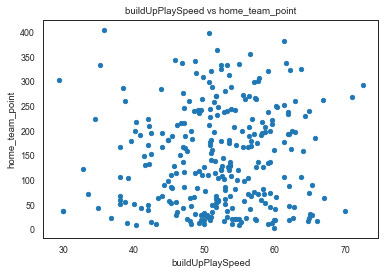

```python
# plotting 'buildUpPlaySpeed' vs 'home_team_point'
with sns.axes_style("white"):
    df_team_perf_combined.plot(x='buildUpPlaySpeed',y='home_team_point',kind='scatter')
    plt.title('buildUpPlaySpeed vs home_team_point');
```

> `buildUpPlaySpeed` doesnt seem to have a strong relation with points

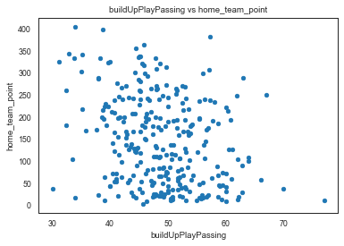

```python
# plotting 'buildUpPlayPassing' vs 'home_team_point'

with sns.axes_style("white"):
    df_team_perf_combined.plot(x='buildUpPlayPassing',y='home_team_point',kind='scatter')
    plt.title('buildUpPlayPassing vs home_team_point');
```

> `buildUpPlayPassing` also doesn't seem to have a strong relation with points

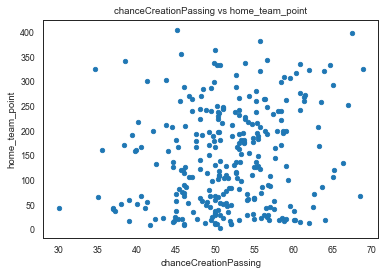

```python
# plotting 'chanceCreationPassing' vs 'home_team_point'

with sns.axes_style("white"):
    df_team_perf_combined.plot(x='chanceCreationPassing',y='home_team_point',kind='scatter')
    plt.title('chanceCreationPassing vs home_team_point');
```

> `chanceCreationPassing` also seems to have no relation with points

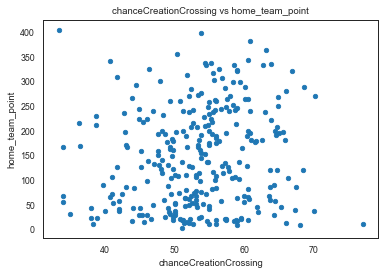

```python
# plotting 'chanceCreationCrossing' vs 'home_team_point'

with sns.axes_style("white"):
    df_team_perf_combined.plot(x='chanceCreationCrossing',y='home_team_point',kind='scatter')
    plt.title('chanceCreationCrossing vs home_team_point');
```

> `chanceCreationCrossing` seems to have a weak positive relation with points

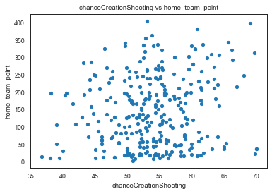

```python
# plotting 'chanceCreationShooting' vs 'home_team_point'

with sns.axes_style("white"):
    df_team_perf_combined.plot(x='chanceCreationShooting',y='home_team_point',kind='scatter')
    plt.title('chanceCreationShooting vs home_team_point');
```

> `chanceCreationShooting` seems to have no relation with points

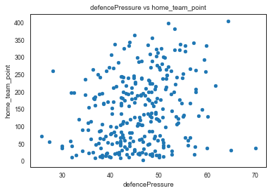

```python
# plotting 'defencePressure' vs 'home_team_point'

with sns.axes_style("white"):
    df_team_perf_combined.plot(x='defencePressure',y='home_team_point',kind='scatter')
    plt.title('defencePressure vs home_team_point');
```

> `defencePressure` seems to also have a weak positive relation with points

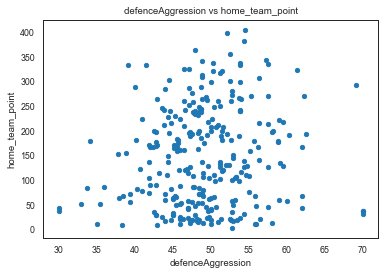

```python
# plotting 'defenceAggression' vs 'home_team_point'

with sns.axes_style("white"):
    df_team_perf_combined.plot(x='defenceAggression',y='home_team_point',kind='scatter')
    plt.title('defenceAggression vs home_team_point');
```

> `defenceAggression` doesn't seems to have a weak relation with points

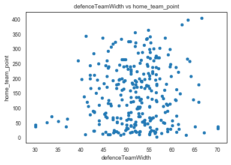

```python
# plotting 'defenceTeamWidth' vs 'home_team_point'

with sns.axes_style("white"):
    df_team_perf_combined.plot(x='defenceTeamWidth',y='home_team_point',kind='scatter')
    plt.title('defenceTeamWidth vs home_team_point');
```

`defenceTeamWidth` also may have a weak positive relation with points

This concludes the work related to Question 3

In this section we:

> - Explored which team had the most victory based on the total points gained
> - Compared the team with most victories with other teams based on the team attributes
> - Looked into any possible relation between the team attributes and the their performance which didn't produce any strong relation

### Research Question 4: Is there any performance difference between the left-footed and right-footed players?

> This question is posed for fun. For this, we would divide the `df_player_att` dataframe to right and left footed player and make some comparisions

```python
# Quick refreshed look at the dataset
df_player_att.head(2)
```

|  | id | player_fifa_api_id | player_api_id | date | overall_rating | potential | preferred_foot | attacking_work_rate | defensive_work_rate | crossing | ... | vision | penalties | marking | standing_tackle | sliding_tackle | gk_diving | gk_handling | gk_kicking | gk_positioning | gk_reflexes |
| --- | --- | --- | --- | --- | --- | --- | --- | --- | --- | --- | --- | --- | --- | --- | --- | --- | --- | --- | --- | --- | --- |
| 0 | 1 | 218353 | 505942 | 2016-02-18 00:00:00 | 67.0 | 71.0 | right | medium | medium | 49.0 | ... | 54.0 | 48.0 | 65.0 | 69.0 | 69.0 | 6.0 | 11.0 | 10.0 | 8.0 | 8.0 |
| 1 | 2 | 218353 | 505942 | 2015-11-19 00:00:00 | 67.0 | 71.0 | right | medium | medium | 49.0 | ... | 54.0 | 48.0 | 65.0 | 69.0 | 69.0 | 6.0 | 11.0 | 10.0 | 8.0 | 8.0 |

2 rows × 42 columns

```python
# Dividing to two dataframe as per their 'preferred_foot'
df_player_att_left = df_player_att[df_player_att['preferred_foot'] == 'left']
df_player_att_left.head(2)
```

|  | id | player_fifa_api_id | player_api_id | date | overall_rating | potential | preferred_foot | attacking_work_rate | defensive_work_rate | crossing | ... | vision | penalties | marking | standing_tackle | sliding_tackle | gk_diving | gk_handling | gk_kicking | gk_positioning | gk_reflexes |
| --- | --- | --- | --- | --- | --- | --- | --- | --- | --- | --- | --- | --- | --- | --- | --- | --- | --- | --- | --- | --- | --- |
| 5 | 6 | 189615 | 155782 | 2016-04-21 00:00:00 | 74.0 | 76.0 | left | high | medium | 80.0 | ... | 66.0 | 59.0 | 76.0 | 75.0 | 78.0 | 14.0 | 7.0 | 9.0 | 9.0 | 12.0 |
| 6 | 7 | 189615 | 155782 | 2016-04-07 00:00:00 | 74.0 | 76.0 | left | high | medium | 80.0 | ... | 66.0 | 59.0 | 76.0 | 75.0 | 78.0 | 14.0 | 7.0 | 9.0 | 9.0 | 12.0 |

2 rows × 42 columns

```python
df_player_att_right = df_player_att[df_player_att['preferred_foot'] == 'right']
df_player_att_right.head(2)
```

|  | id | player_fifa_api_id | player_api_id | date | overall_rating | potential | preferred_foot | attacking_work_rate | defensive_work_rate | crossing | ... | vision | penalties | marking | standing_tackle | sliding_tackle | gk_diving | gk_handling | gk_kicking | gk_positioning | gk_reflexes |
| --- | --- | --- | --- | --- | --- | --- | --- | --- | --- | --- | --- | --- | --- | --- | --- | --- | --- | --- | --- | --- | --- |
| 0 | 1 | 218353 | 505942 | 2016-02-18 00:00:00 | 67.0 | 71.0 | right | medium | medium | 49.0 | ... | 54.0 | 48.0 | 65.0 | 69.0 | 69.0 | 6.0 | 11.0 | 10.0 | 8.0 | 8.0 |
| 1 | 2 | 218353 | 505942 | 2015-11-19 00:00:00 | 67.0 | 71.0 | right | medium | medium | 49.0 | ... | 54.0 | 48.0 | 65.0 | 69.0 | 69.0 | 6.0 | 11.0 | 10.0 | 8.0 | 8.0 |

2 rows × 42 columns

```python
# Checking the new dataframes has correct length
df_player_att.shape[0] == df_player_att_right.shape[0] + df_player_att_left.shape[0]
```

```
True
```

```python
# Getting the mean of all players for the 3 groups of "all players", "left footed players" and "right footer players"
all_players_means = df_player_att.groupby('player_api_id').mean().mean()
rightfooted_players_means = df_player_att_right.groupby('player_api_id').mean().mean()
leftfooted_players_means = df_player_att_left.groupby('player_api_id').mean().mean()
```

> Here We will get a sense of each group's proportion

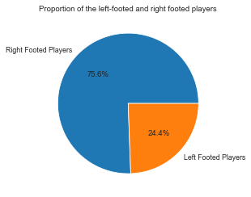

```python
# Setting the plot
labels = 'Right Footed Players','Left Footed Players'
sizes = [df_player_att_right['id'].count(), df_player_att_left['id'].count()]
plt.pie(sizes, labels=labels, autopct='%.1f%%')
plt.title('Proportion of the left-footed and right footed players');
```

> It looks like about 1/4 of the players of left-footed, interesting!

> Let's now try to graphically show all the left-footed and right-footed players on one graph and compare their attributes. This should give us a pretty good indication if there is any difference between the left and right footed players

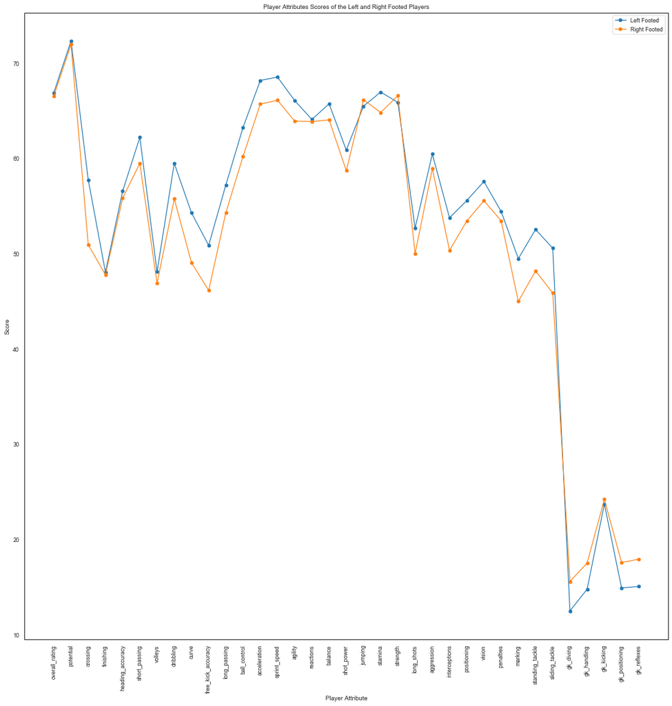

```python
# Here we draw a line plot for the players with left-foot and players with right-foot preference to make some comparision
with sns.axes_style("white"):
    labels = all_players_means.index
    left_footed_means = leftfooted_players_means[2:]
    right_footed_means = rightfooted_players_means[2:]

    fig, ax = plt.subplots(figsize=(18,18))
    ax.plot(labels[2:], left_footed_means, 'o-',label='Left Footed')
    ax.plot(labels[2:], right_footed_means, 'o-', label='Right Footed')
    ax.legend()
    plt.xlabel('Player Attribute')
    plt.ylabel('Score')
    plt.xticks(rotation=90)
    plt.title('Player Attributes Scores of the Left and Right Footed Players');
```

This concludes the work related to Question 4

### Research Question 5: What are the attributes of top 10 players?

> As stated above, for this we would be looking at 'overall_rating' available in 'Player_Attribute' and select the 10 top rated players and compare them with the rest of the players.

```python
# Looking again at the 'df_player_att'
df_player_att.head(5)
```

|  | id | player_fifa_api_id | player_api_id | date | overall_rating | potential | preferred_foot | attacking_work_rate | defensive_work_rate | crossing | ... | vision | penalties | marking | standing_tackle | sliding_tackle | gk_diving | gk_handling | gk_kicking | gk_positioning | gk_reflexes |
| --- | --- | --- | --- | --- | --- | --- | --- | --- | --- | --- | --- | --- | --- | --- | --- | --- | --- | --- | --- | --- | --- |
| 0 | 1 | 218353 | 505942 | 2016-02-18 00:00:00 | 67.0 | 71.0 | right | medium | medium | 49.0 | ... | 54.0 | 48.0 | 65.0 | 69.0 | 69.0 | 6.0 | 11.0 | 10.0 | 8.0 | 8.0 |
| 1 | 2 | 218353 | 505942 | 2015-11-19 00:00:00 | 67.0 | 71.0 | right | medium | medium | 49.0 | ... | 54.0 | 48.0 | 65.0 | 69.0 | 69.0 | 6.0 | 11.0 | 10.0 | 8.0 | 8.0 |
| 2 | 3 | 218353 | 505942 | 2015-09-21 00:00:00 | 62.0 | 66.0 | right | medium | medium | 49.0 | ... | 54.0 | 48.0 | 65.0 | 66.0 | 69.0 | 6.0 | 11.0 | 10.0 | 8.0 | 8.0 |
| 3 | 4 | 218353 | 505942 | 2015-03-20 00:00:00 | 61.0 | 65.0 | right | medium | medium | 48.0 | ... | 53.0 | 47.0 | 62.0 | 63.0 | 66.0 | 5.0 | 10.0 | 9.0 | 7.0 | 7.0 |
| 4 | 5 | 218353 | 505942 | 2007-02-22 00:00:00 | 61.0 | 65.0 | right | medium | medium | 48.0 | ... | 53.0 | 47.0 | 62.0 | 63.0 | 66.0 | 5.0 | 10.0 | 9.0 | 7.0 | 7.0 |

5 rows × 42 columns

```python
# grouping this dataset by the 'player_api_id' and summing all the values
player_att_grouped_sum = df_player_att.groupby(['player_api_id']).sum()
player_att_grouped_sum
```

| player_api_id | id | player_fifa_api_id | overall_rating | potential | crossing | finishing | heading_accuracy | short_passing | volleys | dribbling | ... | vision | penalties | marking | standing_tackle | sliding_tackle | gk_diving | gk_handling | gk_kicking | gk_positioning | gk_reflexes |
| --- | --- | --- | --- | --- | --- | --- | --- | --- | --- | --- | --- | --- | --- | --- | --- | --- | --- | --- | --- | --- | --- |
| 2625 | 1957907 | 2079616 | 842.0 | 856.0 | 702.0 | 662.0 | 648.0 | 791.0 | 532.0 | 758.0 | ... | 774.0 | 867.0 | 881.0 | 894.0 | 792.0 | 174.0 | 180.0 | 267.0 | 145.0 | 146.0 |
| 2752 | 927255 | 2852199 | 1457.0 | 1478.0 | 765.0 | 786.0 | 1582.0 | 1151.0 | 429.0 | 942.0 | ... | 1101.0 | 744.0 | 1493.0 | 1484.0 | 1377.0 | 233.0 | 128.0 | 149.0 | 191.0 | 317.0 |
| 2768 | 1854195 | 2310399 | 1455.0 | 1482.0 | 887.0 | 898.0 | 1400.0 | 1359.0 | 604.0 | 845.0 | ... | 1213.0 | 670.0 | 1505.0 | 1483.0 | 1674.0 | 226.0 | 334.0 | 477.0 | 318.0 | 254.0 |
| 2770 | 1082235 | 2742915 | 1067.0 | 1103.0 | 928.0 | 1015.0 | 1017.0 | 1088.0 | 1007.0 | 1126.0 | ... | 1074.0 | 959.0 | 453.0 | 563.0 | 375.0 | 130.0 | 235.0 | 408.0 | 245.0 | 255.0 |
| 2790 | 25620 | 554045 | 351.0 | 379.0 | 350.0 | 187.0 | 276.0 | 340.0 | 215.0 | 304.0 | ... | 300.0 | 277.0 | 373.0 | 373.0 | 345.0 | 40.0 | 85.0 | 295.0 | 83.0 | 87.0 |
| ... | ... | ... | ... | ... | ... | ... | ... | ... | ... | ... | ... | ... | ... | ... | ... | ... | ... | ... | ... | ... | ... |
| 744907 | 732677 | 2491588 | 571.0 | 725.0 | 467.0 | 489.0 | 522.0 | 654.0 | 467.0 | 621.0 | ... | 566.0 | 577.0 | 434.0 | 533.0 | 544.0 | 93.0 | 148.0 | 137.0 | 126.0 | 93.0 |
| 746419 | 116611 | 467860 | 118.0 | 132.0 | 110.0 | 56.0 | 100.0 | 70.0 | 58.0 | 134.0 | ... | 80.0 | 86.0 | 110.0 | 138.0 | 124.0 | 14.0 | 20.0 | 14.0 | 18.0 | 18.0 |
| 748432 | 120361 | 467938 | 116.0 | 136.0 | 96.0 | 52.0 | 114.0 | 98.0 | 48.0 | 82.0 | ... | 72.0 | 90.0 | 126.0 | 138.0 | 136.0 | 16.0 | 16.0 | 24.0 | 24.0 | 12.0 |
| 750435 | 1326717 | 2029158 | 508.0 | 634.0 | 315.0 | 513.0 | 495.0 | 540.0 | 468.0 | 527.0 | ... | 522.0 | 549.0 | 162.0 | 171.0 | 189.0 | 81.0 | 90.0 | 72.0 | 90.0 | 99.0 |
| 750584 | 16173 | 468282 | 116.0 | 132.0 | 94.0 | 78.0 | 106.0 | 120.0 | 74.0 | 108.0 | ... | 94.0 | 104.0 | 112.0 | 132.0 | 124.0 | 16.0 | 18.0 | 26.0 | 22.0 | 26.0 |

11060 rows × 37 columns

> Selecting the top 10 players based on the `overall_rating`

```python
# Selecting the top 10 players
top_10_players = player_att_grouped_sum.sort_values(by=['overall_rating'], ascending=False).head(10)
top_10_players
```

| player_api_id | id | player_fifa_api_id | overall_rating | potential | crossing | finishing | heading_accuracy | short_passing | volleys | dribbling | ... | vision | penalties | marking | standing_tackle | sliding_tackle | gk_diving | gk_handling | gk_kicking | gk_positioning | gk_reflexes |
| --- | --- | --- | --- | --- | --- | --- | --- | --- | --- | --- | --- | --- | --- | --- | --- | --- | --- | --- | --- | --- | --- |
| 41269 | 374388 | 9990008 | 4402.0 | 4615.0 | 4454.0 | 4065.0 | 3220.0 | 4494.0 | 4087.0 | 4655.0 | ... | 4354.0 | 4314.0 | 1494.0 | 2312.0 | 1897.0 | 450.0 | 795.0 | 662.0 | 697.0 | 541.0 |
| 41890 | 1649572 | 9180130 | 4376.0 | 4542.0 | 4017.0 | 3828.0 | 3492.0 | 4479.0 | 4213.0 | 4304.0 | ... | 4445.0 | 3984.0 | 3500.0 | 4093.0 | 4239.0 | 486.0 | 480.0 | 877.0 | 510.0 | 494.0 |
| 210278 | 8459724 | 10811416 | 4264.0 | 4592.0 | 4198.0 | 3508.0 | 3556.0 | 4421.0 | 3800.0 | 4457.0 | ... | 4200.0 | 3404.0 | 3253.0 | 3632.0 | 3810.0 | 636.0 | 614.0 | 576.0 | 506.0 | 452.0 |
| 26472 | 6624855 | 8417898 | 4145.0 | 4351.0 | 3643.0 | 3365.0 | 3815.0 | 4296.0 | 3691.0 | 3907.0 | ... | 4258.0 | 3813.0 | 3779.0 | 3909.0 | 3903.0 | 361.0 | 737.0 | 1144.0 | 836.0 | 834.0 |
| 30453 | 7316919 | 2123385 | 4060.0 | 4090.0 | 2579.0 | 2154.0 | 4058.0 | 3406.0 | 2991.0 | 2977.0 | ... | 2807.0 | 3090.0 | 4031.0 | 4182.0 | 4156.0 | 278.0 | 288.0 | 689.0 | 412.0 | 555.0 |
| 179795 | 9590986 | 9766151 | 3968.0 | 4330.0 | 3591.0 | 3402.0 | 2629.0 | 3950.0 | 3191.0 | 4430.0 | ... | 3866.0 | 3307.0 | 1331.0 | 2147.0 | 1376.0 | 610.0 | 833.0 | 727.0 | 392.0 | 392.0 |
| 56916 | 902975 | 9164200 | 3868.0 | 4053.0 | 2908.0 | 2741.0 | 3939.0 | 3553.0 | 2812.0 | 2918.0 | ... | 2829.0 | 2718.0 | 3841.0 | 3945.0 | 3856.0 | 258.0 | 706.0 | 888.0 | 662.0 | 574.0 |
| 47394 | 117575 | 8980250 | 3866.0 | 4105.0 | 3760.0 | 3499.0 | 1958.0 | 3836.0 | 3608.0 | 4294.0 | ... | 3830.0 | 3650.0 | 1366.0 | 1439.0 | 1526.0 | 307.0 | 385.0 | 653.0 | 343.0 | 529.0 |
| 30626 | 8160696 | 78000 | 3814.0 | 3850.0 | 3192.0 | 3827.0 | 2780.0 | 3727.0 | 3876.0 | 4023.0 | ... | 3866.0 | 3712.0 | 1213.0 | 1052.0 | 969.0 | 504.0 | 616.0 | 692.0 | 535.0 | 538.0 |
| 25772 | 9350136 | 8601150 | 3814.0 | 4017.0 | 3513.0 | 2895.0 | 3375.0 | 4013.0 | 3190.0 | 3514.0 | ... | 3773.0 | 3799.0 | 3296.0 | 3822.0 | 3712.0 | 343.0 | 691.0 | 815.0 | 431.0 | 699.0 |

10 rows × 37 columns

> Becasue the range of the numbers vary quite a lot, it is a good idea to normalized these values based on the mean value Therfore, we divide the values of top 10 players by the mean of all players

```python
# Normalizing the top 10 players attributes
top_10_players_normal = top_10_players / player_att_grouped_sum.mean()
top_10_players_normal
```

| player_api_id | id | player_fifa_api_id | overall_rating | potential | crossing | finishing | heading_accuracy | short_passing | volleys | dribbling | ... | vision | penalties | marking | standing_tackle | sliding_tackle | gk_diving | gk_handling | gk_kicking | gk_positioning | gk_reflexes |
| --- | --- | --- | --- | --- | --- | --- | --- | --- | --- | --- | --- | --- | --- | --- | --- | --- | --- | --- | --- | --- | --- |
| 41269 | 0.245813 | 3.638132 | 3.875190 | 3.793900 | 4.882803 | 4.917493 | 3.395674 | 4.347196 | 5.041011 | 4.750589 | ... | 4.590389 | 4.736452 | 1.928988 | 2.772967 | 2.411316 | 1.848130 | 2.988760 | 1.903881 | 2.609201 | 1.987122 |
| 41890 | 1.083065 | 3.343193 | 3.852302 | 3.733888 | 4.403731 | 4.630791 | 3.682514 | 4.332686 | 5.196422 | 4.392381 | ... | 4.686329 | 4.374137 | 4.519049 | 4.909063 | 5.388280 | 1.995981 | 1.804535 | 2.522211 | 1.909172 | 1.814489 |
| 210278 | 5.554427 | 3.937270 | 3.753705 | 3.774992 | 4.602157 | 4.243682 | 3.750005 | 4.276580 | 4.687018 | 4.548523 | ... | 4.428028 | 3.737340 | 4.200133 | 4.356149 | 4.842969 | 2.612024 | 2.308300 | 1.656549 | 1.894198 | 1.660221 |
| 26472 | 4.349701 | 3.065606 | 3.648947 | 3.576871 | 3.993725 | 4.070692 | 4.023136 | 4.155664 | 4.552574 | 3.987229 | ... | 4.489177 | 4.186391 | 4.879282 | 4.688377 | 4.961183 | 1.482611 | 2.770712 | 3.290090 | 3.129544 | 3.063327 |
| 30453 | 4.804092 | 0.773288 | 3.574119 | 3.362308 | 2.827290 | 2.605727 | 4.279393 | 3.294737 | 3.689176 | 3.038132 | ... | 2.959399 | 3.392591 | 5.204653 | 5.015808 | 5.282777 | 1.141734 | 1.082721 | 1.981531 | 1.542311 | 2.038545 |
| 179795 | 6.297183 | 3.556609 | 3.493129 | 3.559607 | 3.936719 | 4.115452 | 2.772431 | 3.820966 | 3.935861 | 4.520969 | ... | 4.075894 | 3.630841 | 1.718530 | 2.575069 | 1.749062 | 2.505243 | 3.131619 | 2.090818 | 1.467442 | 1.439837 |
| 56916 | 0.592869 | 3.337392 | 3.405097 | 3.331891 | 3.187964 | 3.315830 | 4.153901 | 3.436935 | 3.468393 | 2.977920 | ... | 2.982593 | 2.984162 | 4.959333 | 4.731555 | 4.901440 | 1.059595 | 2.654170 | 2.553846 | 2.478180 | 2.108333 |
| 47394 | 0.077197 | 3.270402 | 3.403336 | 3.374639 | 4.121989 | 4.232794 | 2.064823 | 3.710690 | 4.450200 | 4.382176 | ... | 4.037940 | 4.007429 | 1.763720 | 1.725908 | 1.939730 | 1.260836 | 1.447387 | 1.877997 | 1.284012 | 1.943046 |
| 30626 | 5.358093 | 0.028406 | 3.357559 | 3.165009 | 3.499305 | 4.629581 | 2.931669 | 3.605251 | 4.780758 | 4.105611 | ... | 4.075894 | 4.075501 | 1.566173 | 1.261748 | 1.231716 | 2.069906 | 2.315819 | 1.990159 | 2.002759 | 1.976103 |
| 25772 | 6.139047 | 3.132342 | 3.357559 | 3.302296 | 3.851209 | 3.502126 | 3.559131 | 3.881908 | 3.934628 | 3.586159 | ... | 3.977845 | 4.171020 | 4.255653 | 4.584031 | 4.718399 | 1.408686 | 2.597778 | 2.343902 | 1.613437 | 2.567465 |

10 rows × 37 columns

> We can now add the name of the players to this list to see who they are

```python
# Adding the name of the top 10 players to the list by merging the two dataframes
top_players_combined = pd.merge(top_10_players_normal, df_player, left_index=True, right_on='player_api_id', how='inner')
top_players_combined.head(2)
```

|  | id_x | player_fifa_api_id_x | overall_rating | potential | crossing | finishing | heading_accuracy | short_passing | volleys | dribbling | ... | gk_kicking | gk_positioning | gk_reflexes | id_y | player_api_id | player_name | player_fifa_api_id_y | birthday | height | weight |
| --- | --- | --- | --- | --- | --- | --- | --- | --- | --- | --- | --- | --- | --- | --- | --- | --- | --- | --- | --- | --- | --- |
| 395 | 0.245813 | 3.638132 | 3.875190 | 3.793900 | 4.882803 | 4.917493 | 3.395674 | 4.347196 | 5.041011 | 4.750589 | ... | 1.903881 | 2.609201 | 1.987122 | 396 | 41269 | Alessio Cerci | 178393 | 1987-07-23 00:00:00 | 180.34 | 172 |
| 1860 | 1.083065 | 3.343193 | 3.852302 | 3.733888 | 4.403731 | 4.630791 | 3.682514 | 4.332686 | 5.196422 | 4.392381 | ... | 2.522211 | 1.909172 | 1.814489 | 1863 | 41890 | Claudio Marchisio | 173210 | 1986-01-19 00:00:00 | 180.34 | 157 |

2 rows × 44 columns

> We can now create a general bar chart of the normalized values for better visualizations and see how the top 10 players compare with the rest of the players

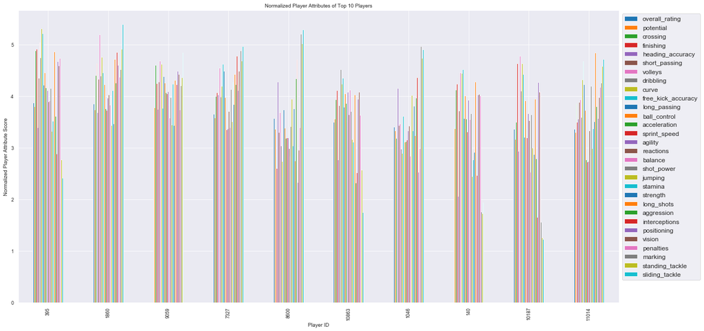

```python
# Dropping the unnecessary columns for better visualization
columns_to_drop = ['id_x', 'player_fifa_api_id_x','gk_kicking','gk_positioning', 'gk_reflexes','gk_diving','gk_handling',
                   'id_y','player_api_id','player_fifa_api_id_y','birthday','height','weight']

top_players_combined_cleaned =  top_players_combined.drop(columns_to_drop,axis = 1)

# x_labels = top_players_combined['player_name'].tolist()
# Not sure why I can't assign this on x-axis!

#plottong bar chart of top 10 players attributes
with sns.axes_style("darkgrid"):
    ax = top_players_combined_cleaned.plot.bar(rot = 90, figsize=(20,10))
    ax.get_legend_handles_labels()
    ax.legend(loc='upper left', fontsize=12, bbox_to_anchor=(1, 1))
    plt.xlabel('Player ID')
    plt.ylabel('Normalized Player Attribute Score')
    plt.title('Normalized Player Attributes of Top 10 Players')
```

> The bar charts also have a general down trend from left to right where left would be player # 1 and the right is player # 10

This concludes the work related to Question 5

## Limitations

This study encompasses few limitations which we discuss below based on the question we are trying to answer:

> Q1: *What teams improved the most over the time period?* The method we utilized here is based on the linear regression and determining the steepest slope. While this mathematically is a sound approach, linear regression really excels when there is a reasonable amount of data available. In this study, we selected the season as one of the variables which depending on the team's appearance in the game, could vary from 1 to 8 seasons. One season appearance would be meaningless to begin with and the teams with 2 appearance, even though it is possible to fit a line through, yields low confidence in the analysis. Incidentally, the team we found to have the steepest slope, meaning greatest seasonal improvement, happened to be a team that only appeared in 2 seasons. Therefore, this puts some limitations on the strength of the chosen method that needs to be taken into account

> Q2: *Which players had the most penalties?* The main limitation is the fact that the value we used is assumed to be the right value to look at. My preliminary investigation on whether this value means this is the number of the penalties a player scored did not find anything. Therefore, the results shown for this analysis rely on this assumption being true.

> Q3: *What team attributes lead to the most victories?* The plots as illustrated above did not show any strong relationship between the teams’ victory and the team attributes. This was done purely based on the visualizations and without any statistical analysis such as Pearson correlation or likewise. To better quantify the relation, it would be useful to carry out some statistical analysis and establish the correlations quantitatively

> Q4: *Is there any performance difference between the left-footed and right-footed players?* This analysis, same as above, was an illustrative analysis and there is not significant analytical analyses done on this. There are potential to improve the comparison made in this section by carrying out further quantitative investigation

> Q5: *What are the attributes of top 10 players?* We limited the study to top 10 players and did the analysis based on the available available attributes. The overall rating where the ranking of the top 10 players was based upon is just one number selected from the table and there might be more inclusive way to rank the players from top to bottom rather than looking at one number